# Affinity purification-mass spectrometry network analysis

Kristina Hanspers, Alexander Pico

2019-10-18

*The R markdown is available from the pulldown menu for* Code *at the upper-right, choose “Download Rmd”, or [download the Rmd from GitHub](https://raw.githubusercontent.com/cytoscape/cytoscape-automation/master/for-scripters/R/notebooks/AP-MS-network-analysis.Rmd).*

This vignette describes how to use data from an affinity purification-mass spectrometry experiment to generate relevant interaction networks, enriching the networks with information from public resources, analyzing the networks and creating effective visualizations.

The result of this vignette will be a visualization of a human-HIV integrated network combining experimental data and publicly available interaction data.

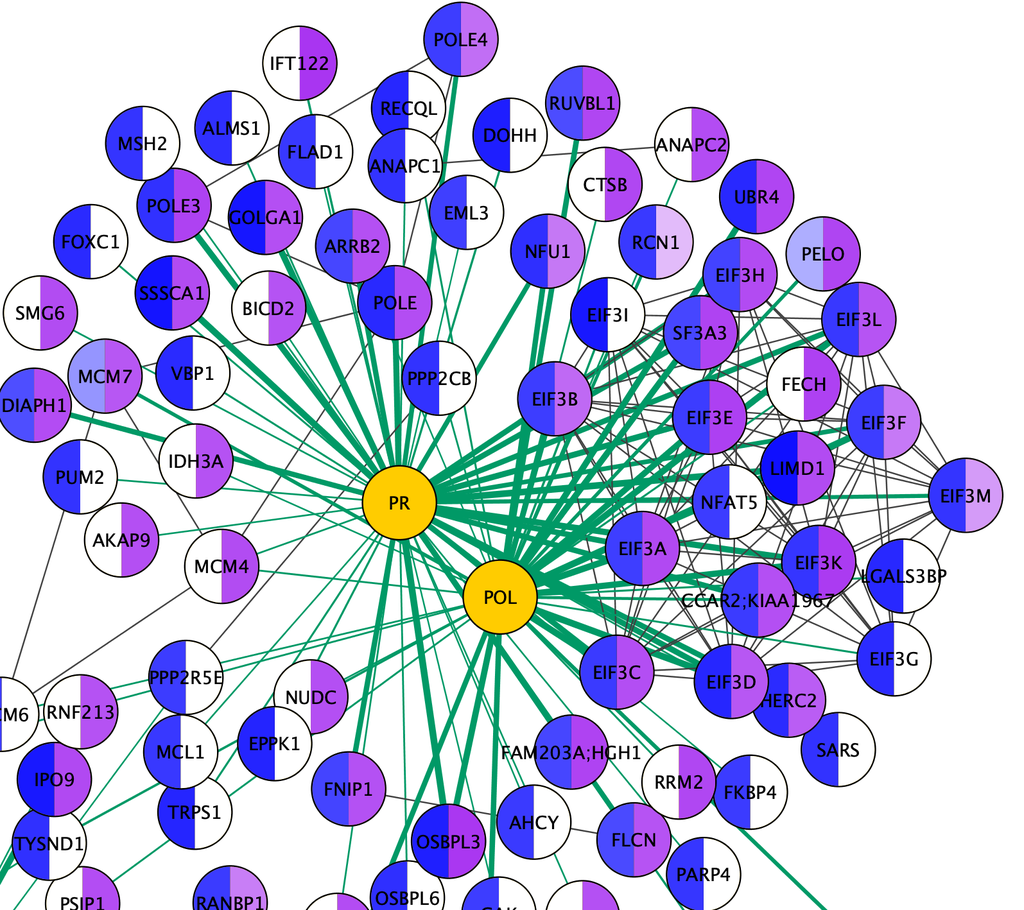

# Installation

```r
if(!"RCy3" %in% installed.packages()){
    install.packages("BiocManager")
    BiocManager::install("RCy3")
}
library(RCy3)

if(!"RColorBrewer" %in% installed.packages()){
    install.packages("RColorBrewer")
}
library(RColorBrewer)
```

# Prerequisites

In addition to this package (RCy3), you will need:

- **Cytoscape 3.7** or greater, which can be downloaded from https://cytoscape.org/download.html. Simply follow the installation instructions on screen.
- Complete installation wizard
- Launch Cytoscape For this vignette, you’ll also need the STRING app and the enhancedGraphics app:
- Install the STRING app from https://apps.cytoscape.org/apps/stringapp
- Install the enhancedGraphics app from http://apps.cytoscape.org/apps/enhancedgraphics

```r
#available in Cytoscape 3.7.0 and above
installApp('stringApp')
installApp('enhancedGraphics')
```